# Sequential Monte Carlo methods in NIMBLE

BYU Summer Institute on Applied Statistics workshop

NIMBLE Development Team

# Stochastic volatility example

Here’s a common SMC example, following Pitt and Shephard (1999). The idea is that financial time series often have time-varying variability that is of interest to financial folks.

Let $r_t$ be the exchange rate at time $t$ and $y_t$ be 100 times the daily log return of the exchange rate, $y_t = 100 (\log(r_t) - \log(r_{t-1}))$. A standard stochastic volatility model is

$$y_t = \epsilon_t \beta \exp\left(\frac{x_t}{2}),$$
$$\epsilon_t \sim N(0,1)$$
$$x_t = \phi x_{t-1} + \nu_t, \nu_t \sim N(0, \sigma^2)$$

Here $\beta$ is the constant volatility while $x_t$ is the latent evolving volatility.

For our basic SMC implementation we’ll take $\beta$, $\sigma^2$, and $\phi$ to be known values, but we’ll do inference on them via particle MCMC in the next module.

# Stochastic volatility BUGS code

```r
stochVolCode <- nimbleCode({
  x[1] ~ dnorm(phi * x0, sd = sigma)
  y[1] ~ dnorm(0, var = betaSquared * exp(x[1]))
  for(t in 2:T){
        x[t] ~ dnorm(phi * x[t-1], sd = sigma)
        y[t] ~ dnorm(0, var = betaSquared * exp(x[t]))
  }
  x0 ~ dnorm(1, sd = sigma)
  phi <- 2 * phiStar - 1
  phiStar ~ dbeta(18, 1)
  sigma ~ T(dt(mu = 0, sigma = 1, df = 1), 0, )
  betaSquared <- beta^2
  beta ~ T(dt(mu = 0, sigma = 1, df = 1), 0, )
})
```

# Stochastic volatility filtering

Now let’s create the model and apply and run a bootstrap filter.

```r
library('stochvol')
data('exrates')
y <- 100 * logret(exrates$USD[exrates$date > '2012-02-01'])
TT <- 44
stochVolModel <- nimbleModel(code = stochVolCode,
   constants = list(T = TT), data = list(y = y),
   inits = list(beta = .5992, phi = .9702,
   sigma = .178, x0 = 0))
```

```
## defining model...
```

```
## building model...
```

```
## setting data and initial values...
```

```
## running calculate on model (any error reports that follow may simply reflect missing values in model variables) ...
## checking model sizes and dimensions... This model is not fully initialized. This is not an error. To see which variables are not initialized, use model$initializeInfo(). For more information on model initialization, see help(modelInitialization).
## model building finished.
```

```r
CstochVolModel <- compileNimble(stochVolModel)
```

```
## compiling... this may take a minute. Use 'showCompilerOutput = TRUE' to see C++ compiler details.
## compilation finished.
```

```r
svBootFilter <- buildBootstrapFilter(stochVolModel, nodes = 'x',
                       control = list(saveAll = TRUE, thresh = .9))
cSvBootFilter <- compileNimble(svBootFilter, project = stochVolModel)
```

```
## compiling... this may take a minute. Use 'showCompilerOutput = TRUE' to see C++ compiler details.
```

```
## compilation finished.
```

```r
cSvBootFilter$run(10000)
```

```
## [1] -40.46805
```

```r
samples <- as.matrix(cSvBootFilter$mvEWSamples) ## equally-weighted samples from filtering distribution
```

# Stochastic volatility results

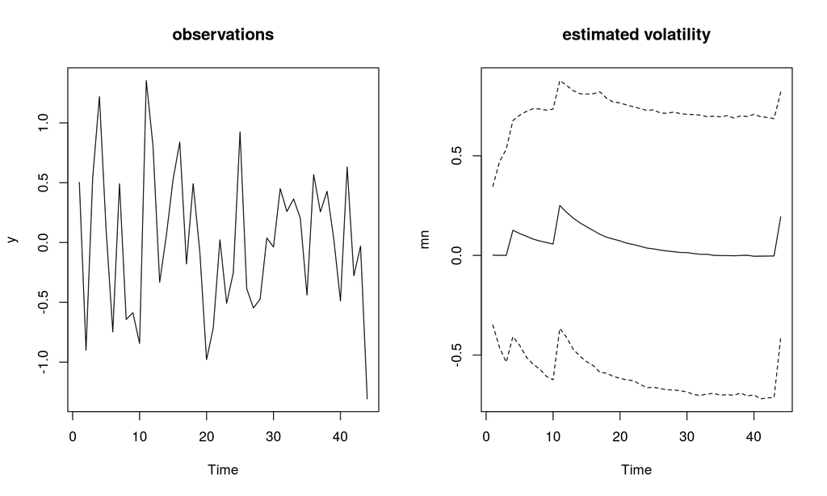

```r
par(mfrow = c(1,2))
ts.plot(y, main = 'observations')
mn <- apply(samples, 2, mean)
qs <- apply(samples, 2, quantile, c(.025, .975))
ts.plot(mn, ylim = range(qs), main = 'estimated volatility')
lines(1:TT, qs[1, ], lty = 2)
lines(1:TT, qs[2, ], lty = 2)
```

[perhaps try out the ‘smoothing=TRUE’ setting?][if no resampling, in what sense is mvEWsamples equally weighted] [why in boot filter do we have new weights not calculated based on old weights]

# SMC algorithm implementation

Our SMC algorithms are implemented using nimbleFunctions (of course!).

Each time step has its own nimbleFunction, because we need fully model-generic calculations that can’t assume any particular structure for a given time step (and at the moment NIMBLE can’t easily store model dependencies for multiple nodes in a single data strucutre).

We’ll look directly at the code in `filtering_bootstrap.R`.

The overall filtering nimbleFunction simply iterates through each individual time step function and builds up the overall likelihood from the time step-specific pieces.